# Smoothing: A. Density Estimation

Michaela Lukacova

2024-09-12

*Implement a kernel density estimator using the Epanechnikov kernel, and implement one or more bandwidth selection algorithms using either AMISE plug-in methods or cross-validation methods. Test the implementation and compare the results with the results of using density() in R.*

*It may be a good idea to use real data to investigate how the bandwidth selection works, but for benchmarking and profiling it is best to use simulated data. Think about how to make your implementation as general and generic as possible.*

# Kernel density estimators

The kernel density estimators approximate the unknown density of data points with the function

$$\hat{f}(x) = \frac{1}{hN} \sum_{j=1}^N
K\left(\frac{x-x_j}{h}\right)$$
For a given kernel $K: \mathbb{R} \rightarrow \mathbb{R}$ and bandwidth parameter $h$.

## Naive density estimator

We first implement a naive kernel density estimator. It computes density estimates along a grid of points. The number of gridpoints is given by $m$ (default 512). We use the Epanechnikov kernel:

$$K(x) = \frac{3}{4} (1-x^2)1_{[-1,1]}(x)$$

The naive kernal density estimator takes as input $x$ and a bandwidth parameter $h$.

```r
kern_dens_naive <- function(x, h, m = 512) {

  rg <- range(x)
  xx <- seq(rg[1] - 3 * h, rg[2] + 3 * h, length.out = m)
  y <- numeric(m)
  for (i in seq_along(xx)) {
    condition <- x - h <= xx[i] & (xx[i] <= x + h)
    y[i] <- sum((1 - (xx[i] - x)^2 / h^2) * condition)
  }
  y <- 3 * y / (4 * h * length(x))
  list(x = xx, y = y)

}
```

We check how the naive kernel density estimator approximates data with an arbitrary bandwidth parameter.

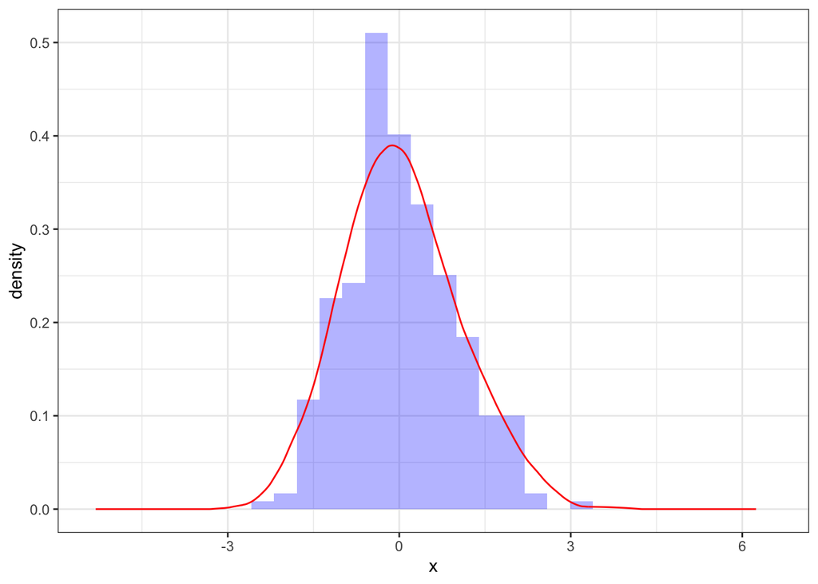

```r
# Simulate data
n <- 300
set.seed(123)
x <- rnorm(n)

# Compute kernel density estimates along grid
dens_est <- as.data.frame(kern_dens_naive(x, h = 1)[1:2])

# Plot along with kernel
ggplot(tibble(x = x), aes(x = x, y = ..density..)) +
   geom_histogram(bins = 30, fill = "blue", alpha = 0.3) +
   geom_line(data = dens_est, aes(x = x, y = y), color = "red")
```

The approximation looks quite good.

## Binned density estimator

The binned density estimator is an alteration of the previous density estimator. It has the advantage of computational efficiency. The binned density estimator is computed as

$$\hat{f}(x) = \frac{1}{hN} \sum_{i=1}^B n_j K\left(\frac{x-c_j}{h}\right)$$
The function bins the observations into $B$ equal length bins spanning the length of $x$ observations. The number of observations in each bin is $n_j$. $c_j$ is the center of each bin. The computational efficiency is achieved by, instead of computing $K$ in each data point, we only compute $K$ in each centerpoint, and then multiply by the number of observations in that bin. The concern could be that we lose accuracy, but as we’ll see, this is not a problem.

```r
# Function computing the percentage of observations in each bin
kern_bin <- function(x, l, u, B) {
  w <- numeric(B)
  delta <- (u - l) / (B - 1)
  for (j in seq_along(x)) {
    i <- floor((x[j] - l) / delta + 0.5) + 1
    w[i] <- w[i] + 1
  }
  w / sum(w)
}

# Binned kernel estimator
kern_dens_bin <- function(x, h, m = 512, B = 100) {
  rg <- range(x)
  delta <- (rg[2] - rg[1]) / (B - 1)
  c <- seq(rg[1] + delta/2, rg[2] - delta/2, length.out = B)
  n <- kern_bin(x, rg[1], rg[2], B)

  xx <- seq(rg[1] - 3 * h, rg[2] + 3 * h, length.out = m)
  y <- numeric(m)

  for (i in seq_along(xx)) {
    condition <- c - h <= xx[i] & (xx[i] <= c + h)
    y[i] <- sum(n * (1 - (xx[i] - c)^2 / h^2) * condition)
  }

  y <- 3 * y / (4 * h)
  list(x = xx, y = y)
}
```

We check how the binned kernel density estimator approximates data with an arbitrary bandwidth parameter.

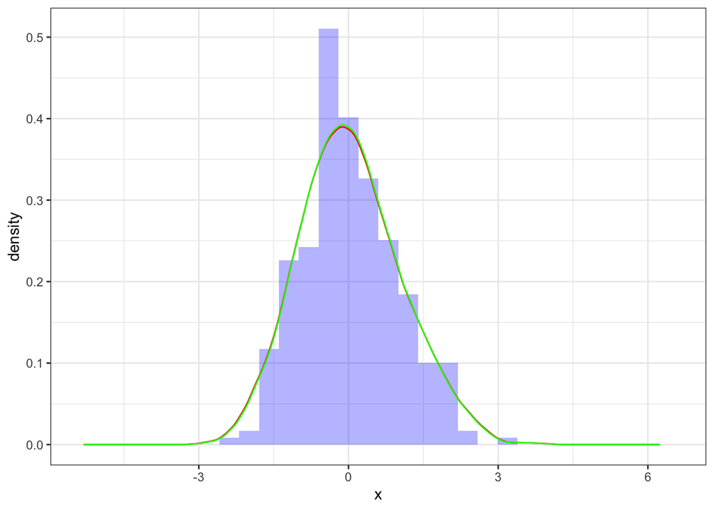

```r
# Compute kernel density estimates along grid
dens_est2 <- as.data.frame(kern_dens_bin(x, h = 1)[1:2])

# Plot along with kernel
ggplot(tibble(x = x), aes(x = x, y = ..density..)) +
  geom_histogram(bins = 30, fill = "blue", alpha = 0.3) +
  geom_line(data = dens_est, aes(x = x, y = y), color = "red")+
  geom_line(data = dens_est2, aes(x = x, y = y), color = "green")
```

Differences in the two functions

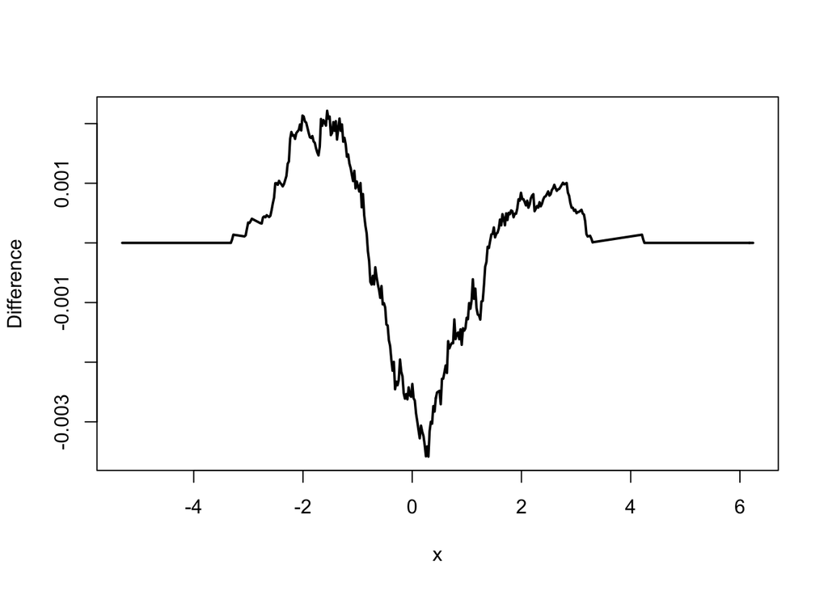

```r
plot(
  kern_dens_naive(x,1)$x,
  kern_dens_naive(x,1)$y - kern_dens_bin(x, 1)$y,
  type = "l",
  lwd = 2,
  xlab = "x",
  ylab = "Difference"
)
```

```r
test_that("Our binned density implementation corresponds to the naive", {
  expect_equal(
    kern_dens_naive(x,1)$y,
    kern_dens_bin(x, 1)$y,
    tolerance = 1e-2
  )
})
```

```
## Test passed 🌈
```

# Bandwidth selection

## AMISE plug-in

The Epanechnikov kernel is a square-integrable probability density with mean 0. It can be shown that

$$\sigma_K^2 &= \frac{1}{5} \\
||K||_2^2 &= \frac{3}{5}$$

For the Epanechnikov kernel. The AMISE is defined as